# Table of Contents

```python
import pandas as pd
import seaborn as sns
import matplotlib.pyplot as plt
import matplotlib
import numpy as np
from matplotlib.ticker import (MultipleLocator, FormatStrFormatter, AutoMinorLocator)
import collections
import math
from sklearn.linear_model import LogisticRegression
from sklearn.preprocessing import LabelEncoder
from sklearn.preprocessing import StandardScaler
from sklearn.multiclass import OneVsRestClassifier
import phik
# импорт библиотек pandas, seaborn, matplotlib.pyplot, numpy, sklearn
import warnings
warnings.filterwarnings('ignore')
pd.set_option('display.max_columns', None)
%config InlineBackend.figure_format='jpg'
```

## Изучение общей информации из файла

```python
teams_df = pd.read_excel('/Users/galina/Desktop/Финальный проект/match_df_cor.xlsx')
# чтение файла с данными и сохранение в teams_df
```

```python
teams_df.head()
# вывод первых 5 строк датафрейма
```

|  | Unnamed: 0 | id | country_id | country | league_id | league | season | stage | date | year | month_year | match_api_id | team_api_id | team_fifa_api_id | team_long_name | opposing_team_api_id | opposing_team_long_name | goals_scored | missed_goals | place | B365 | BW | IW | LB | PS | WH | SJ | VC | GB | … |
| --- | --- | --- | --- | --- | --- | --- | --- | --- | --- | --- | --- | --- | --- | --- | --- | --- | --- | --- | --- | --- | --- | --- | --- | --- | --- | --- | --- | --- | --- | --- |
| 0 | 0 | 307 | 1 | Belgium | 1 | Belgium Jupiler League | 2009/2010 | 1 | 2009-07-31 00:00:00 | 2009 | 2009-07-01 | 665318 | 9985 | 232.0 | Standard de Liège | 9997 | Sint-Truidense VV | 2 | 2 | home | 1.22 | 1.20 | 1.2 | 1.17 | NaN | 1.2 | 1.18 | 1.20 | 1.20 | … |
| 1 | 1 | 308 | 1 | Belgium | 1 | Belgium Jupiler League | 2009/2010 | 1 | 2009-08-02 00:00:00 | 2009 | 2009-08-01 | 665320 | 9986 | 670.0 | Sporting Charleroi | 8342 | Club Brugge KV | 1 | 2 | home | 2.50 | 2.60 | 2.6 | 2.40 | NaN | 2.5 | 2.50 | 2.80 | 2.60 | … |
| 2 | 2 | 309 | 1 | Belgium | 1 | Belgium Jupiler League | 2009/2010 | 1 | 2009-08-02 00:00:00 | 2009 | 2009-08-01 | 665321 | 9984 | 1750.0 | KSV Cercle Brugge | 9991 | KAA Gent | 1 | 3 | home | 2.88 | 2.75 | 2.4 | 2.70 | NaN | 2.5 | 2.80 | 2.62 | 2.70 | … |
| 3 | 3 | 310 | 1 | Belgium | 1 | Belgium Jupiler League | 2009/2010 | 1 | 2009-08-01 00:00:00 | 2009 | 2009-08-01 | 665322 | 9994 | 2007.0 | Sporting Lokeren | 10000 | SV Zulte-Waregem | 1 | 1 | home | 2.30 | 2.05 | 2.0 | 2.20 | NaN | 2.0 | 2.05 | 2.00 | 2.10 | … |
| 4 | 4 | 311 | 1 | Belgium | 1 | Belgium Jupiler League | 2009/2010 | 1 | 2009-08-01 00:00:00 | 2009 | 2009-08-01 | 665323 | 8571 | 100081.0 | KV Kortrijk | 8635 | RSC Anderlecht | 0 | 2 | home | 5.75 | 5.50 | 5.0 | 5.50 | NaN | 5.0 | 6.50 | 5.50 | 5.25 | … |

Добавляем столбцы с **результатом** матча для каждой команды на разных этапах, **разрывом** по числу голов и **id** команды-победителя.

```python
teams_df['goals_diff'] = abs(teams_df['goals_scored'] - teams_df['missed_goals'])
# подсчёт разницы по забитым мячам
```

```python
def calc_result(df):
    if df['goals_scored'] > df['missed_goals']:
        return 'win'
    elif df['goals_scored'] < df['missed_goals']:
        return 'lose'
    else:
        return 'draw'
# функция для категоризации исхода матча
```

```python
teams_df['result'] = teams_df.apply(calc_result, axis=1)
# применение функции calc_result
```

```python
def get_win_name(df):
    if df['goals_scored'] > df['missed_goals']:
        return df['team_api_id']
    elif df['goals_scored'] < df['missed_goals']:
        return df['opposing_team_api_id']
    else:
        return 'draw'
# функция для получения id команды-победителя
```

```python
teams_df['win_name'] = teams_df.apply(get_win_name, axis=1)
# применение функции get_win_name
```

Рассмотрим характеристики датафрейма подробнее.

```python
def get_df_info(df):
    display(df.head(10))
    display(df.info())
    display(df.describe(include='all'))
    display(df.columns)
# создание функции для вывода характеристик датафрейма
```

```python
get_df_info(teams_df)
# применение функции get_df_info
```

|  | Unnamed: 0 | id | country_id | country | league_id | league | season | stage | date | year | month_year | match_api_id | team_api_id | team_fifa_api_id | team_long_name | opposing_team_api_id | opposing_team_long_name | goals_scored | missed_goals | place | B365 | BW | IW | LB | PS | WH | SJ | VC | GB | … |
| --- | --- | --- | --- | --- | --- | --- | --- | --- | --- | --- | --- | --- | --- | --- | --- | --- | --- | --- | --- | --- | --- | --- | --- | --- | --- | --- | --- | --- | --- | --- |
| 0 | 0 | 307 | 1 | Belgium | 1 | Belgium Jupiler League | 2009/2010 | 1 | 2009-07-31 00:00:00 | 2009 | 2009-07-01 | 665318 | 9985 | 232.0 | Standard de Liège | 9997 | Sint-Truidense VV | 2 | 2 | home | 1.22 | 1.20 | 1.20 | 1.17 | NaN | 1.20 | 1.18 | 1.20 | 1.20 | … |
| 1 | 1 | 308 | 1 | Belgium | 1 | Belgium Jupiler League | 2009/2010 | 1 | 2009-08-02 00:00:00 | 2009 | 2009-08-01 | 665320 | 9986 | 670.0 | Sporting Charleroi | 8342 | Club Brugge KV | 1 | 2 | home | 2.50 | 2.60 | 2.60 | 2.40 | NaN | 2.50 | 2.50 | 2.80 | 2.60 | … |
| 2 | 2 | 309 | 1 | Belgium | 1 | Belgium Jupiler League | 2009/2010 | 1 | 2009-08-02 00:00:00 | 2009 | 2009-08-01 | 665321 | 9984 | 1750.0 | KSV Cercle Brugge | 9991 | KAA Gent | 1 | 3 | home | 2.88 | 2.75 | 2.40 | 2.70 | NaN | 2.50 | 2.80 | 2.62 | 2.70 | … |
| 3 | 3 | 310 | 1 | Belgium | 1 | Belgium Jupiler League | 2009/2010 | 1 | 2009-08-01 00:00:00 | 2009 | 2009-08-01 | 665322 | 9994 | 2007.0 | Sporting Lokeren | 10000 | SV Zulte-Waregem | 1 | 1 | home | 2.30 | 2.05 | 2.00 | 2.20 | NaN | 2.00 | 2.05 | 2.00 | 2.10 | … |
| 4 | 4 | 311 | 1 | Belgium | 1 | Belgium Jupiler League | 2009/2010 | 1 | 2009-08-01 00:00:00 | 2009 | 2009-08-01 | 665323 | 8571 | 100081.0 | KV Kortrijk | 8635 | RSC Anderlecht | 0 | 2 | home | 5.75 | 5.50 | 5.00 | 5.50 | NaN | 5.00 | 6.50 | 5.50 | 5.25 | … |
| 5 | 5 | 312 | 1 | Belgium | 1 | Belgium Jupiler League | 2009/2010 | 1 | 2009-08-01 00:00:00 | 2009 | 2009-08-01 | 665324 | 8203 | 110724.0 | KV Mechelen | 10001 | KVC Westerlo | 4 | 1 | home | 2.30 | 2.30 | 2.20 | 2.25 | NaN | 2.25 | 2.38 | 2.30 | 2.30 | … |
| 6 | 6 | 313 | 1 | Belgium | 1 | Belgium Jupiler League | 2009/2010 | 1 | 2009-08-01 00:00:00 | 2009 | 2009-08-01 | 665325 | 9999 | 546.0 | KSV Roeselare | 9993 | Beerschot AC | 1 | 1 | home | 2.90 | 2.55 | 2.30 | 2.60 | NaN | 2.50 | 2.60 | 2.55 | 2.60 | … |
| 7 | 7 | 314 | 1 | Belgium | 1 | Belgium Jupiler League | 2009/2010 | 10 | 2009-10-04 00:00:00 | 2009 | 2009-10-01 | 665411 | 8342 | 231.0 | Club Brugge KV | 8635 | RSC Anderlecht | 4 | 2 | home | 2.50 | 2.45 | 2.30 | 2.40 | NaN | 2.60 | 2.50 | 2.40 | 2.45 | … |
| 8 | 8 | 315 | 1 | Belgium | 1 | Belgium Jupiler League | 2009/2010 | 10 | 2009-10-04 00:00:00 | 2009 | 2009-10-01 | 665412 | 9985 | 232.0 | Standard de Liège | 9987 | KRC Genk | 1 | 0 | home | 1.50 | 1.50 | 1.45 | 1.50 | NaN | 1.44 | 1.50 | 1.44 | 1.50 | … |
| 9 | 9 | 316 | 1 | Belgium | 1 | Belgium Jupiler League | 2009/2010 | 10 | 2009-10-03 00:00:00 | 2009 | 2009-10-01 | 665413 | 9997 | 680.0 | Sint-Truidense VV | 10000 | SV Zulte-Waregem | 1 | 2 | home | 2.50 | 2.30 | 2.30 | 2.25 | NaN | 2.40 | 2.50 | 2.38 | 2.35 | … |

```
<class 'pandas.core.frame.DataFrame'>
RangeIndex: 45306 entries, 0 to 45305
Data columns (total 72 columns):
 #   Column                             Non-Null Count  Dtype
---  ------                             --------------  -----
 0   Unnamed: 0                         45306 non-null  int64
 1   id                                 45306 non-null  int64
 2   country_id                         45306 non-null  int64
 3   country                            45306 non-null  object
 4   league_id                          45306 non-null  int64
 5   league                             45306 non-null  object
 6   season                             45306 non-null  object
 7   stage                              45306 non-null  int64
 8   date                               45306 non-null  object
 9   year                               45306 non-null  int64
```

[output cut: 64 more lines]

```
None
```

|  | Unnamed: 0 | id | country_id | country | league_id | league | season | stage | date | year | month_year | match_api_id | team_api_id | team_fifa_api_id | team_long_name | opposing_team_api_id | opposing_team_long_name | goals_scored | missed_goals | place | B365 | BW | IW | LB | PS | WH | SJ | VC | GB | … |
| --- | --- | --- | --- | --- | --- | --- | --- | --- | --- | --- | --- | --- | --- | --- | --- | --- | --- | --- | --- | --- | --- | --- | --- | --- | --- | --- | --- | --- | --- | --- |
| count | 45306.000000 | 45306.000000 | 45306.000000 | 45306 | 45306.000000 | 45306 | 45306 | 45306.000000 | 45306 | 45306.000000 | 45306 | 4.530600e+04 | 45306.000000 | 45112.000000 | 45306 | 45306.000000 | 45306 | 45306.000000 | 45306.000000 | 45306 | 39388.000000 | 39360.000000 | 39270.000000 | 39324.000000 | 22336.000000 | 39366.000000 | 28398.000000 | 39346.000000 | 22532.000000 | … |
| unique | NaN | NaN | NaN | 11 | NaN | 11 | 7 | NaN | 1491 | NaN | 78 | NaN | NaN | NaN | 283 | NaN | 283 | NaN | NaN | 2 | NaN | NaN | NaN | NaN | NaN | NaN | NaN | NaN | NaN | … |
| top | NaN | NaN | NaN | England | NaN | England Premier League | 2015/2016 | NaN | 2015-04-04 00:00:00 | NaN | 2014-03-01 | NaN | NaN | NaN | St. Johnstone FC | NaN | Manchester United | NaN | NaN | home | NaN | NaN | NaN | NaN | NaN | NaN | NaN | NaN | NaN | … |
| freq | NaN | NaN | NaN | 5320 | NaN | 5320 | 6652 | NaN | 110 | NaN | 886 | NaN | NaN | NaN | 266 | NaN | 266 | NaN | NaN | 22653 | NaN | NaN | NaN | NaN | NaN | NaN | NaN | NaN | NaN | … |
| mean | 22652.500000 | 13200.298018 | 11788.478391 | NaN | 11788.478391 | NaN | NaN | 18.231934 | NaN | 2012.510131 | NaN | 1.296034e+06 | 10131.973138 | 16347.917339 | NaN | 10131.973138 | NaN | 1.359974 | 1.359974 | NaN | 3.666994 | 3.504062 | 3.329668 | 3.497493 | 3.894596 | 3.572249 | 3.613177 | 3.820880 | 3.449716 | … |
| std | 13078.859985 | 7449.110583 | 7531.134941 | NaN | 7531.134941 | NaN | NaN | 10.405998 | NaN | 2.068498 | NaN | 4.487886e+05 | 15070.818109 | 37850.928366 | NaN | 15070.818109 | NaN | 1.242820 | 1.242820 | NaN | 3.168188 | 2.829025 | 2.471332 | 2.909657 | 3.683784 | 3.050086 | 3.088675 | 3.659761 | 2.629055 | … |
| min | 0.000000 | 307.000000 | 1.000000 | NaN | 1.000000 | NaN | NaN | 1.000000 | NaN | 2009.000000 | NaN | 6.538650e+05 | 1601.000000 | 1.000000 | NaN | 1601.000000 | NaN | 0.000000 | 0.000000 | NaN | 1.040000 | 1.030000 | 1.030000 | 1.040000 | 1.040000 | 1.020000 | 1.040000 | 1.030000 | 1.050000 | … |
| 25% | 11326.250000 | 6730.000000 | 4769.000000 | NaN | 4769.000000 | NaN | NaN | 9.000000 | NaN | 2011.000000 | NaN | 8.755240e+05 | 8472.000000 | 80.000000 | NaN | 8472.000000 | NaN | 0.000000 | 0.000000 | NaN | 1.910000 | 1.910000 | 1.900000 | 1.910000 | 1.980000 | 1.950000 | 1.910000 | 1.950000 | 1.900000 | … |
| 50% | 22652.500000 | 13079.000000 | 10257.000000 | NaN | 10257.000000 | NaN | NaN | 18.000000 | NaN | 2012.000000 | NaN | 1.229280e+06 | 8697.000000 | 472.000000 | NaN | 8697.000000 | NaN | 1.000000 | 1.000000 | NaN | 2.630000 | 2.600000 | 2.600000 | 2.600000 | 2.750000 | 2.620000 | 2.630000 | 2.700000 | 2.600000 | … |
| 75% | 33978.750000 | 19528.000000 | 17642.000000 | NaN | 17642.000000 | NaN | NaN | 27.000000 | NaN | 2014.000000 | NaN | 1.718028e+06 | 9925.000000 | 1895.000000 | NaN | 9925.000000 | NaN | 2.000000 | 2.000000 | NaN | 4.000000 | 3.900000 | 3.700000 | 3.800000 | 4.200000 | 4.000000 | 4.000000 | 4.100000 | 3.900000 | … |
| max | 45305.000000 | 25979.000000 | 24558.000000 | NaN | 24558.000000 | NaN | NaN | 38.000000 | NaN | 2016.000000 | NaN | 2.216672e+06 | 274581.000000 | 112513.000000 | NaN | 274581.000000 | NaN | 10.000000 | 10.000000 | NaN | 51.000000 | 51.000000 | 25.000000 | 51.000000 | 47.500000 | 51.000000 | 41.000000 | 67.000000 | 34.000000 | … |

```
Index(['Unnamed: 0', 'id', 'country_id', 'country', 'league_id', 'league',
       'season', 'stage', 'date', 'year', 'month_year', 'match_api_id',
       'team_api_id', 'team_fifa_api_id', 'team_long_name',
       'opposing_team_api_id', 'opposing_team_long_name', 'goals_scored',
       'missed_goals', 'place', 'B365', 'BW', 'IW', 'LB', 'PS', 'WH', 'SJ',
       'VC', 'GB', 'BS', 'buildUpPlaySpeed', 'buildUpPlayDribbling',
       'buildUpPlayPassing', 'chanceCreationPassing', 'chanceCreationCrossing',
       'chanceCreationShooting', 'defencePressure', 'defenceAggression',
       'defenceTeamWidth', 'avg_overall_rating', 'avg_potential',
       'avg_finishing', 'avg_heading_accuracy', 'avg_dribbling', 'avg_curve',
       'avg_free_kick_accuracy', 'avg_ball_control', 'avg_acceleration',
       'avg_sprint_speed', 'avg_agility', 'avg_reactions', 'avg_shot_power',
       'avg_jumping', 'avg_stamina', 'avg_strength', 'avg_long_shots',
       'avg_interceptions', 'avg_positioning', 'avg_vision', 'avg_penalties',
       'avg_marking', 'avg_standing_tackle', 'avg_sliding_tackle',
       'avg_gk_diving', 'avg_gk_handling', 'avg_gk_kicking',
       'avg_gk_positioning', 'avg_gk_reflexes',
       'number_of_players_with_rating>=85', 'goals_diff', 'result',
       'win_name'],
      dtype='object')
```

В данных присутствуют пропуски среди атрибутов игроков, командных показателей и букмекерских коэффициентов. Для дальнейшей работы с датами нужно перевести столбец `date` в тип datetime.

Удалим ненужные столбцы.

```python
teams_df = teams_df.drop(['Unnamed: 0', 'SJ', 'GB', 'BS'], axis=1)
# удаление столбцов методом drop
```

Подсчитаем медианные букмекерские коэффициенты для команд по матчам.

```python
teams_df['avg_coeff'] = teams_df[['B365', 'BW', 'IW', 'LB', 'PS', 'WH', 'VC']].median(axis=1)
# подсчёт медианных коэффициентов по строкам
```

```python
teams_df = teams_df.drop(['B365', 'BW', 'IW', 'LB', 'PS', 'WH', 'VC'], axis=1)
# удаление столбцов методом drop
```

```python
teams_df.head()
# вывод первых 5 строк датафрейма
```

|  | id | country_id | country | league_id | league | season | stage | date | year | month_year | match_api_id | team_api_id | team_fifa_api_id | team_long_name | opposing_team_api_id | opposing_team_long_name | goals_scored | missed_goals | place | buildUpPlaySpeed | buildUpPlayDribbling | buildUpPlayPassing | chanceCreationPassing | chanceCreationCrossing | chanceCreationShooting | defencePressure | defenceAggression | defenceTeamWidth | avg_overall_rating | … |
| --- | --- | --- | --- | --- | --- | --- | --- | --- | --- | --- | --- | --- | --- | --- | --- | --- | --- | --- | --- | --- | --- | --- | --- | --- | --- | --- | --- | --- | --- | --- |
| 0 | 307 | 1 | Belgium | 1 | Belgium Jupiler League | 2009/2010 | 1 | 2009-07-31 00:00:00 | 2009 | 2009-07-01 | 665318 | 9985 | 232.0 | Standard de Liège | 9997 | Sint-Truidense VV | 2 | 2 | home | NaN | NaN | NaN | NaN | NaN | NaN | NaN | NaN | NaN | 71.808501 | … |
| 1 | 308 | 1 | Belgium | 1 | Belgium Jupiler League | 2009/2010 | 1 | 2009-08-02 00:00:00 | 2009 | 2009-08-01 | 665320 | 9986 | 670.0 | Sporting Charleroi | 8342 | Club Brugge KV | 1 | 2 | home | NaN | NaN | NaN | NaN | NaN | NaN | NaN | NaN | NaN | NaN | … |
| 2 | 309 | 1 | Belgium | 1 | Belgium Jupiler League | 2009/2010 | 1 | 2009-08-02 00:00:00 | 2009 | 2009-08-01 | 665321 | 9984 | 1750.0 | KSV Cercle Brugge | 9991 | KAA Gent | 1 | 3 | home | NaN | NaN | NaN | NaN | NaN | NaN | NaN | NaN | NaN | 64.778758 | … |
| 3 | 310 | 1 | Belgium | 1 | Belgium Jupiler League | 2009/2010 | 1 | 2009-08-01 00:00:00 | 2009 | 2009-08-01 | 665322 | 9994 | 2007.0 | Sporting Lokeren | 10000 | SV Zulte-Waregem | 1 | 1 | home | NaN | NaN | NaN | NaN | NaN | NaN | NaN | NaN | NaN | 65.599830 | … |
| 4 | 311 | 1 | Belgium | 1 | Belgium Jupiler League | 2009/2010 | 1 | 2009-08-01 00:00:00 | 2009 | 2009-08-01 | 665323 | 8571 | 100081.0 | KV Kortrijk | 8635 | RSC Anderlecht | 0 | 2 | home | NaN | NaN | NaN | NaN | NaN | NaN | NaN | NaN | NaN | 63.521323 | … |

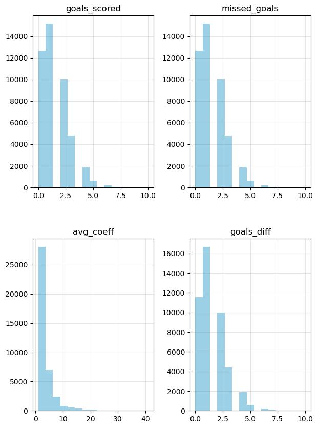

```python
matplotlib.rcParams['grid.color'] = 'gray'
matplotlib.rcParams['grid.alpha'] = 0.2
ax = teams_df[['goals_scored',
               'missed_goals',
               'avg_coeff',
               'goals_diff']].hist(figsize=(7, 10),
                                   color='#9CD0E6',
                                   bins=15)
# вывод гистограмм для числовых столбцов таблицы
```

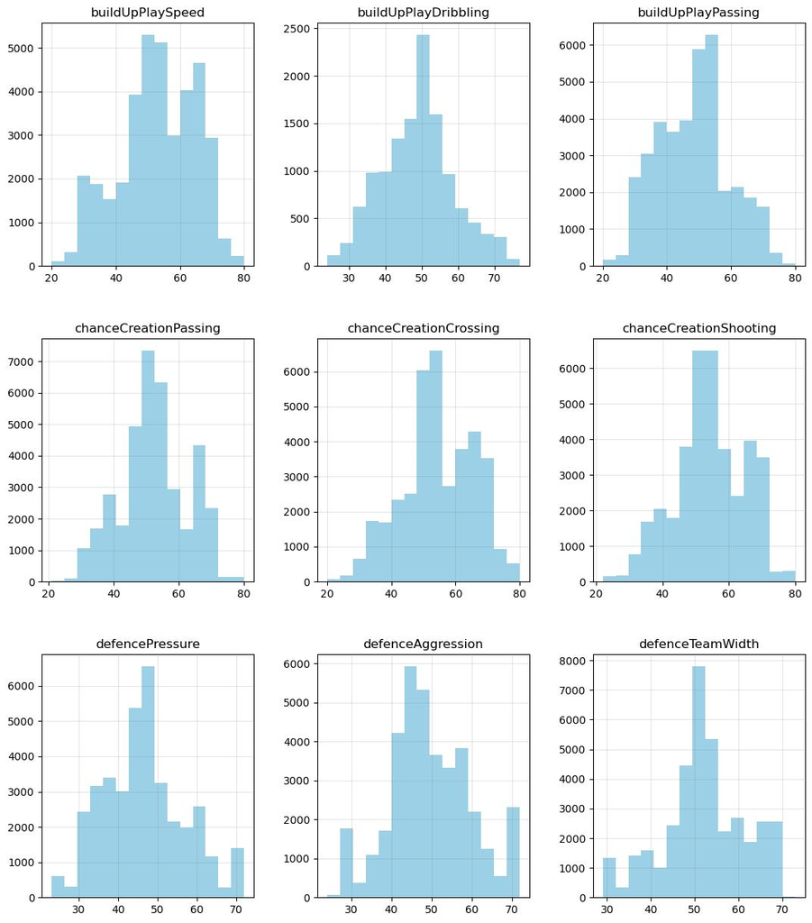

```python
matplotlib.rcParams['grid.color'] = 'gray'
matplotlib.rcParams['grid.alpha'] = 0.2
ax = teams_df[['buildUpPlaySpeed', 'buildUpPlayDribbling', 'buildUpPlayPassing',
               'chanceCreationPassing', 'chanceCreationCrossing',
               'chanceCreationShooting', 'defencePressure', 'defenceAggression',
               'defenceTeamWidth']].hist(figsize=(13, 15),
                                         color='#9CD0E6',
                                         bins=15)
# вывод гистограмм для числовых столбцов таблицы
```

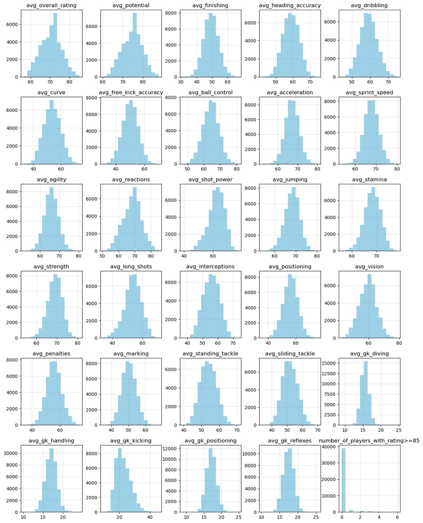

```python
matplotlib.rcParams['grid.color'] = 'gray'
matplotlib.rcParams['grid.alpha'] = 0.2
ax = teams_df[['avg_overall_rating', 'avg_potential',
               'avg_finishing', 'avg_heading_accuracy', 'avg_dribbling', 'avg_curve',
               'avg_free_kick_accuracy', 'avg_ball_control', 'avg_acceleration',
               'avg_sprint_speed', 'avg_agility', 'avg_reactions', 'avg_shot_power',
               'avg_jumping', 'avg_stamina', 'avg_strength', 'avg_long_shots',
               'avg_interceptions', 'avg_positioning', 'avg_vision', 'avg_penalties',
               'avg_marking', 'avg_standing_tackle', 'avg_sliding_tackle',
               'avg_gk_diving', 'avg_gk_handling', 'avg_gk_kicking',
               'avg_gk_positioning', 'avg_gk_reflexes',
               'number_of_players_with_rating>=85']].hist(figsize=(15, 20),
                                                          color='#9CD0E6',
                                                          bins=15)
# вывод гистограмм для числовых столбцов таблицы
```

## Предобработка данных

### Проверка на наличие дубликатов

```python
print(teams_df.duplicated().sum())
# подсчёт явных дубликатов
```

```
0
```

```python
len(teams_df['match_api_id'].unique())
# подсчёт уникальных id матчей
```

```
22653
```

Всего за все сезоны было проведено **22653 матчей**. Один и тот же матч отображается 2 раза, так как для одной команды он был *домашним*, а для другой - *выездным*. Результаты конкретного матча для каждой команды с уникальными характеристиками выводим по-отдельности.

```python
teams_df['match_api_id'].value_counts()
# количество уникальных совпадений в колонке 'match_api_id'
```

```
665318     2
1722113    2
1994620    2
1994619    2
1994618    2
          ..
1030379    2
1030376    2
1030374    2
1030372    2
1992095    2
Name: match_api_id, Length: 22653, dtype: int64
```

```python
len(teams_df['team_api_id'].unique())
# подсчёт уникальных id команд
```

```
285
```

```python
len(teams_df['opposing_team_api_id'].unique())
# подсчёт уникальных id команд-соперников
```

```
285
```

```python
intersection_list = set(list(teams_df['team_api_id'].unique())).intersection(set(list(teams_df['opposing_team_api_id'].unique())))
len(intersection_list)
# проверка пересечения id команд
```

```
285
```

Уникальных команд в датасете - **285**.

```python
for column in ['stage', 'place', 'league', 'country', 'result']:
    print(f'Категориальный признак {column}, уникальные значения:')
    print('')
    print(teams_df[column].unique())
    print('')
    print('')
# вывод уникальных значений для категориальных признаков с помощью цикла
```

```
Категориальный признак stage, уникальные значения:

[ 1 10 11 12 13 14 15 16 17 18 19  2 20 21 22 23 24 25 26 27 28 29  3 30
  4  5  6  7  8  9 31 32 33 34 35 36 37 38]


Категориальный признак place, уникальные значения:

['home' 'away']


Категориальный признак league, уникальные значения:

['Belgium Jupiler League' 'England Premier League' 'France Ligue 1'
 'Germany 1. Bundesliga' 'Italy Serie A' 'Netherlands Eredivisie'
 'Poland Ekstraklasa' 'Portugal Liga ZON Sagres' 'Scotland Premier League'
 'Spain LIGA BBVA' 'Switzerland Super League']


Категориальный признак country, уникальные значения:

['Belgium' 'England' 'France' 'Germany' 'Italy' 'Netherlands' 'Poland'
 'Portugal' 'Scotland' 'Spain' 'Switzerland']


Категориальный признак result, уникальные значения:

['draw' 'lose' 'win']
```

### Изменение типов данных

```python
teams_df['date'] = pd.to_datetime(teams_df['date'], format='%Y-%m-%d %H:%M:%S')
teams_df['month_year'] = pd.to_datetime(teams_df['month_year'], format='%Y-%m-%d %H:%M:%S')
# перевод столбца 'date' в формат datetime
```

```python
print(f'Мы располагаем данными за период с {str(teams_df["date"].dt.date.min())} по {str(teams_df["date"].dt.date.max())}.')
```

```
Мы располагаем данными за период с 2009-07-11 по 2016-05-25.
```

```python
len(teams_df['date'].unique())
# подсчёт уникальных дат матчей
```

```
1491
```

## Исследовательский анализ данных

```python
league_grouped = (teams_df
                     .groupby(['season', 'country', 'league'])
                     .agg(stage_num = ('stage', 'nunique'),
                          match_num = ('match_api_id', 'nunique'),
                          teams_num = ('team_api_id', 'nunique'),
                          team_avg_goals = ('goals_scored', 'mean'),
                          goals_sum = ('goals_scored', 'sum'),
                          avg_goals_diff = ('goals_diff', 'mean'))
                     .reset_index()
                 )
league_grouped['match_avg_goals'] = league_grouped['goals_sum'] / league_grouped['match_num']
league_grouped.sort_values(by='match_avg_goals', ascending=False)
# группировка по сезонам и лигам с подсчётом среднего количества голов за матч
```

|  | season | country | league | stage_num | match_num | teams_num | team_avg_goals | goals_sum | avg_goals_diff | match_avg_goals |
| --- | --- | --- | --- | --- | --- | --- | --- | --- | --- | --- |
| 10 | 2009/2010 | Switzerland | Switzerland Super League | 36 | 180 | 10 | 1.663889 | 599 | 1.705556 | 3.327778 |
| 27 | 2011/2012 | Netherlands | Netherlands Eredivisie | 34 | 306 | 18 | 1.629085 | 997 | 1.754902 | 3.258170 |
| 16 | 2010/2011 | Netherlands | Netherlands Eredivisie | 34 | 306 | 18 | 1.612745 | 987 | 1.604575 | 3.225490 |
| 49 | 2013/2014 | Netherlands | Netherlands Eredivisie | 34 | 306 | 18 | 1.598039 | 978 | 1.437908 | 3.196078 |
| 47 | 2013/2014 | Germany | Germany 1. Bundesliga | 34 | 306 | 18 | 1.580065 | 967 | 1.598039 | 3.160131 |
| ... | ... | ... | ... | ... | ... | ... | ... | ... | ... | ... |
| 17 | 2010/2011 | Poland | Poland Ekstraklasa | 30 | 240 | 16 | 1.204167 | 578 | 1.283333 | 2.408333 |
| 51 | 2013/2014 | Portugal | Portugal Liga ZON Sagres | 30 | 240 | 16 | 1.185417 | 569 | 1.279167 | 2.370833 |
| 13 | 2010/2011 | France | France Ligue 1 | 38 | 380 | 20 | 1.171053 | 890 | 1.105263 | 2.342105 |
| 6 | 2009/2010 | Poland | Poland Ekstraklasa | 30 | 240 | 16 | 1.108333 | 532 | 1.158333 | 2.216667 |
| 28 | 2011/2012 | Poland | Poland Ekstraklasa | 30 | 240 | 16 | 1.097917 | 527 | 1.204167 | 2.195833 |

77 rows × 10 columns

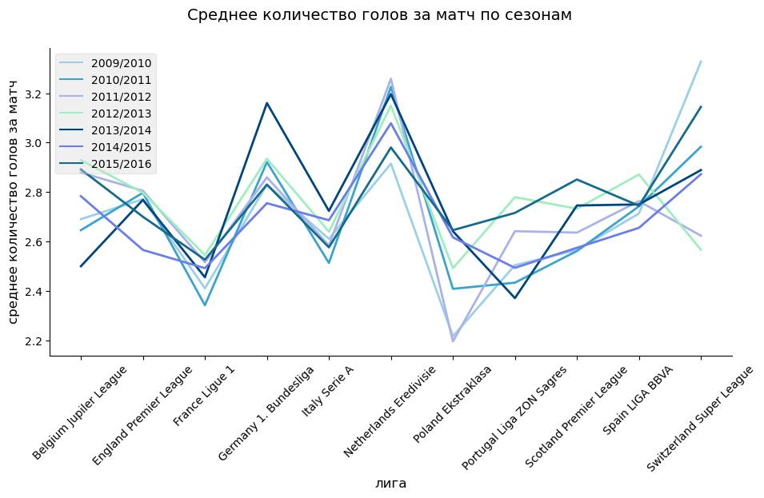

```python
fig = plt.figure(figsize=(11, 5))
fig.suptitle('Среднее количество голов за матч по сезонам', fontsize=14)
ax1 = fig.add_subplot(1, 1, 1)
ax1.spines['top'].set_visible(False)
ax1.spines['right'].set_visible(False)

sns.lineplot(data=league_grouped,
             x='league',
             y='match_avg_goals',
             hue='season',
             ax=ax1,
             palette=['#9CD0E6', '#3BA3D0', '#A9B2EB', '#A0EDBF', '#00457E', '#6B7DEB', '#166A8E'],
             linewidth=2)

plt.xticks(rotation = 45)
ax1.set_xlabel('лига', fontsize=12)
ax1.set_ylabel('среднее количество голов за матч', fontsize=12)
ax1.legend(loc='upper left',
           facecolor='#dbdbdb',
           framealpha=0.4)

plt.show()
# построение линейных графиков по сезонам
```

```python
teams_goals_grouped = (teams_df
                         .groupby(['season', 'league', 'team_long_name', 'place'])
                         .agg(match_num = ('match_api_id', 'nunique'),
                              team_avg_goals = ('goals_scored', 'mean'),
                              goals_sum = ('goals_scored', 'sum'),
                              avg_goals_diff = ('goals_diff', 'mean'))
                         .reset_index()
                      )
teams_goals_grouped
# группировка по сезонам и командам
```

|  | season | league | team_long_name | place | match_num | team_avg_goals | goals_sum | avg_goals_diff |
| --- | --- | --- | --- | --- | --- | --- | --- | --- |
| 0 | 2009/2010 | Belgium Jupiler League | Beerschot AC | away | 14 | 0.714286 | 10 | 1.214286 |
| 1 | 2009/2010 | Belgium Jupiler League | Beerschot AC | home | 14 | 1.428571 | 20 | 1.714286 |
| 2 | 2009/2010 | Belgium Jupiler League | Club Brugge KV | away | 14 | 2.000000 | 28 | 1.357143 |
| 3 | 2009/2010 | Belgium Jupiler League | Club Brugge KV | home | 14 | 1.714286 | 24 | 1.000000 |
| 4 | 2009/2010 | Belgium Jupiler League | KAA Gent | away | 14 | 1.642857 | 23 | 1.357143 |
| ... | ... | ... | ... | ... | ... | ... | ... | ... |
| 2577 | 2015/2016 | Switzerland Super League | FC Zürich | home | 18 | 1.611111 | 29 | 1.166667 |
| 2578 | 2015/2016 | Switzerland Super League | Grasshopper Club Zürich | away | 18 | 1.666667 | 30 | 1.166667 |
| 2579 | 2015/2016 | Switzerland Super League | Grasshopper Club Zürich | home | 18 | 1.944444 | 35 | 1.777778 |
| 2580 | 2015/2016 | Switzerland Super League | Lugano | away | 18 | 1.166667 | 21 | 1.944444 |
| 2581 | 2015/2016 | Switzerland Super League | Lugano | home | 18 | 1.388889 | 25 | 1.777778 |

2582 rows × 8 columns

```python
def show_top_teams_goals(season_name):
    fig = plt.figure(figsize=(11, 5))
    fig.suptitle(f'Топ-7 команд по среднему числу голов за матч в сезоне {season_name}:',
                 fontsize=14)
    ax1 = fig.add_subplot(1, 2, 1)
    ax2 = fig.add_subplot(1, 2, 2)
    ax1.spines['top'].set_visible(False)
    ax1.spines['right'].set_visible(False)
    ax2.spines['top'].set_visible(False)
    ax2.spines['right'].set_visible(False)

    (teams_goals_grouped
         .query(f'place == "home" and season == "{season_name}"')
         .head(7)
         .sort_values(by='team_avg_goals', ascending=False)
         .plot(x='team_long_name',
               y='team_avg_goals',
               kind='bar',
               color='#2F70AF',
               legend=False,
               ax=ax1,
               width=0.6)
    )

    (teams_goals_grouped
         .query(f'place == "away" and season == "{season_name}"')
         .head(7)
         .sort_values(by='team_avg_goals', ascending=False)
         .plot(x='team_long_name',
               y='team_avg_goals',
               kind='bar',
               color='#9CD0E6',
               legend=False,
               ax=ax2,
               width=0.6)
    )

    plt.xticks(rotation = 45)
    ax1.set_title('играли дома', fontsize=14, loc='left')
    ax2.set_title('играли в гостях', fontsize=14, loc='left')
    ax1.set_xlabel('команда', fontsize=12)
    ax2.set_xlabel('команда', fontsize=12)
    ax1.set_ylabel('среднее число голов за матч', fontsize=12)
    ax1.set_xticklabels(teams_goals_grouped
                            .query(f'place == "home" and season == "{season_name}"')
                            .head(7)
                            .sort_values(by='team_avg_goals', ascending=False)['team_long_name'],
                        rotation=45)

    return plt.show()
    # функция для построения столбчатых диарамм
```

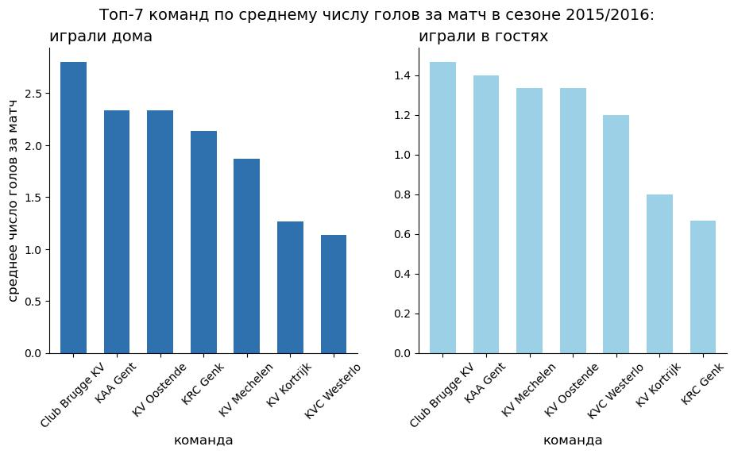

```python
show_top_teams_goals('2015/2016')
# построение столбчатых диаграмм для сезона 2015/2016
```

```python
teams_results_grouped = (teams_df
                             .pivot_table(index=['season', 'league', 'team_long_name', 'place'],
                                          columns='result',
                                          values='team_api_id',
                                          aggfunc='count')
                             .reset_index()
                        )
# группировка по сезонам и командам с числом выигранных матчей
teams_results_grouped.columns = ['season', 'league', 'team_long_name', 'place', 'draw', 'lose', 'win']
# переименование колонок
teams_match_num = (teams_df
                     .groupby(['season', 'league', 'team_long_name', 'place'])['match_api_id']
                     .count()
                     .reset_index()
                  )
# группировка по сезонам и командам с общим числом матчей
teams_match_num.columns = ['season', 'league', 'team_long_name', 'place', 'match_num']
```

```python
teams_results_grouped = teams_results_grouped.merge(teams_match_num,
                                                    on=['season', 'league', 'team_long_name', 'place'],
                                                    how='left')
# объединение таблиц
teams_results_grouped
```

|  | season | league | team_long_name | place | draw | lose | win | match_num |
| --- | --- | --- | --- | --- | --- | --- | --- | --- |
| 0 | 2009/2010 | Belgium Jupiler League | Beerschot AC | away | 4.0 | 7.0 | 3.0 | 14 |
| 1 | 2009/2010 | Belgium Jupiler League | Beerschot AC | home | 4.0 | 4.0 | 6.0 | 14 |
| 2 | 2009/2010 | Belgium Jupiler League | Club Brugge KV | away | 3.0 | 4.0 | 7.0 | 14 |
| 3 | 2009/2010 | Belgium Jupiler League | Club Brugge KV | home | 3.0 | 1.0 | 10.0 | 14 |
| 4 | 2009/2010 | Belgium Jupiler League | KAA Gent | away | 4.0 | 3.0 | 7.0 | 14 |
| ... | ... | ... | ... | ... | ... | ... | ... | ... |
| 2577 | 2015/2016 | Switzerland Super League | FC Zürich | home | 7.0 | 7.0 | 4.0 | 18 |
| 2578 | 2015/2016 | Switzerland Super League | Grasshopper Club Zürich | away | 5.0 | 7.0 | 6.0 | 18 |
| 2579 | 2015/2016 | Switzerland Super League | Grasshopper Club Zürich | home | 3.0 | 6.0 | 9.0 | 18 |
| 2580 | 2015/2016 | Switzerland Super League | Lugano | away | 4.0 | 11.0 | 3.0 | 18 |
| 2581 | 2015/2016 | Switzerland Super League | Lugano | home | 4.0 | 8.0 | 6.0 | 18 |

2582 rows × 8 columns

```python
def show_top_teams_wins(season_name):
    fig = plt.figure(figsize=(11, 5))
    fig.suptitle(f'Топ-7 команд по количеству выигранных матчей в сезоне {season_name}:',
                 fontsize=14)
    ax1 = fig.add_subplot(1, 2, 1)
    ax2 = fig.add_subplot(1, 2, 2)
    ax1.spines['top'].set_visible(False)
    ax1.spines['right'].set_visible(False)
    ax2.spines['top'].set_visible(False)
    ax2.spines['right'].set_visible(False)

    (teams_results_grouped
         .query(f'place == "home" and season == "{season_name}"')
         .head(7)
         .sort_values(by='win', ascending=False)
         .plot(x='team_long_name',
               y='win',
               kind='bar',
               color='#2F70AF',
               legend=False,
               ax=ax1,
               width=0.6)
    )

    (teams_results_grouped
         .query(f'place == "away" and season == "{season_name}"')
         .head(7)
         .sort_values(by='win', ascending=False)
         .plot(x='team_long_name',
               y='win',
               kind='bar',
               color='#9CD0E6',
               legend=False,
               ax=ax2,
               width=0.6)
    )

    plt.xticks(rotation = 45)
    ax1.set_title('играли дома', fontsize=14, loc='left')
    ax2.set_title('играли в гостях', fontsize=14, loc='left')
    ax1.set_xlabel('команда', fontsize=12)
    ax2.set_xlabel('команда', fontsize=12)
    ax1.set_ylabel('число выигранных матчей', fontsize=12)
    ax1.set_xticklabels(teams_results_grouped
                            .query(f'place == "home" and season == "{season_name}"')
                            .head(7)
                            .sort_values(by='win', ascending=False)['team_long_name'],
                        rotation=45)

    return plt.show()
    # функция для построения столбчатых диарамм
```

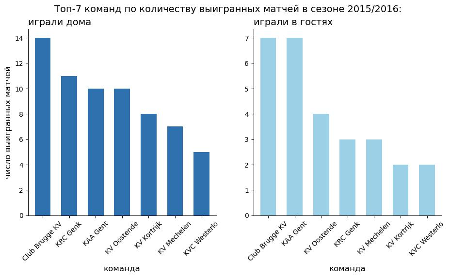

```python
show_top_teams_wins('2015/2016')
# построение столбчатых диаграмм для сезона 2015/2016
```

## Корреляционный анализ

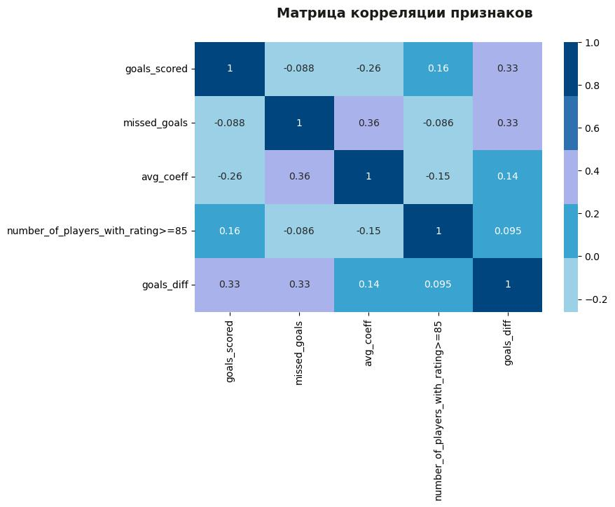

```python
fig = plt.figure(figsize=(8, 5))
fig.suptitle('Матрица корреляции признаков',
             fontsize=14,
             fontweight='demi',
             color='#1B1B17')
ax1 = fig.add_subplot(1, 1, 1)
sns.heatmap(teams_df[['goals_scored',
                      'missed_goals',
                      'avg_coeff',
                      'number_of_players_with_rating>=85',
                      'goals_diff']].corr(),
            ax=ax1,
            cmap=['#9CD0E6', '#3BA3D0', '#A9B2EB', '#2F70AF', '#00457E'],
            annot=True)

plt.show()
# построение тепловой карты
```

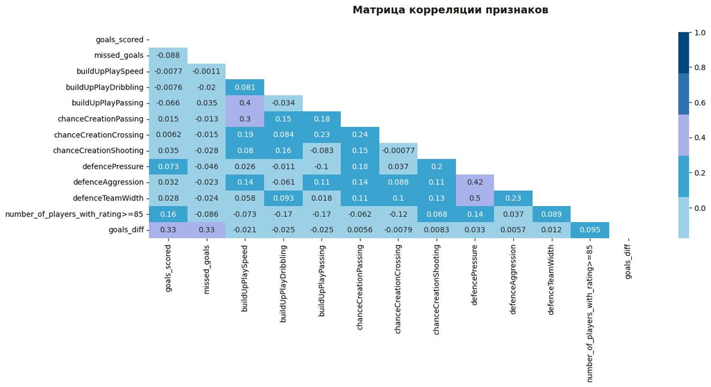

```python
fig = plt.figure(figsize=(15, 5))
fig.suptitle('Матрица корреляции признаков',
             fontsize=14,
             fontweight='demi',
             color='#1B1B17')
ax1 = fig.add_subplot(1, 1, 1)
corrmat = teams_df[['goals_scored',
                    'missed_goals',
                    'buildUpPlaySpeed', 'buildUpPlayDribbling', 'buildUpPlayPassing',
                    'chanceCreationPassing', 'chanceCreationCrossing',
                    'chanceCreationShooting', 'defencePressure', 'defenceAggression',
                    'defenceTeamWidth',
                    'number_of_players_with_rating>=85',
                    'goals_diff']].corr()
mask= np.zeros_like(corrmat)
mask[np.triu_indices_from(mask)] = True
sns.heatmap(corrmat,
            ax=ax1,
            cmap=['#9CD0E6', '#3BA3D0', '#A9B2EB', '#2F70AF', '#00457E'],
            vmax=1,
            annot=True,
            mask=mask)

plt.show()
# построение тепловой карты
```

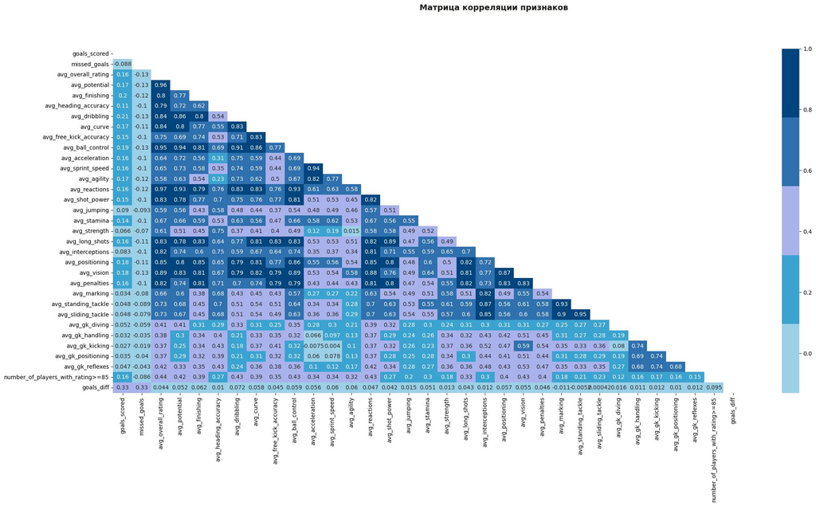

```python
fig = plt.figure(figsize=(25, 11))
fig.suptitle('Матрица корреляции признаков',
             fontsize=14,
             fontweight='demi',
             color='#1B1B17')
ax1 = fig.add_subplot(1, 1, 1)
corrmat = teams_df[['goals_scored',
                    'missed_goals',
                    'avg_overall_rating', 'avg_potential',
                    'avg_finishing', 'avg_heading_accuracy', 'avg_dribbling', 'avg_curve',
                    'avg_free_kick_accuracy', 'avg_ball_control', 'avg_acceleration',
                    'avg_sprint_speed', 'avg_agility', 'avg_reactions', 'avg_shot_power',
                    'avg_jumping', 'avg_stamina', 'avg_strength', 'avg_long_shots',
                    'avg_interceptions', 'avg_positioning', 'avg_vision', 'avg_penalties',
                    'avg_marking', 'avg_standing_tackle', 'avg_sliding_tackle',
                    'avg_gk_diving', 'avg_gk_handling', 'avg_gk_kicking',
                    'avg_gk_positioning', 'avg_gk_reflexes',
                    'number_of_players_with_rating>=85',
                    'goals_diff']].corr()
mask= np.zeros_like(corrmat)
mask[np.triu_indices_from(mask)] = True
sns.heatmap(corrmat,
            ax=ax1,
            cmap=['#9CD0E6', '#3BA3D0', '#A9B2EB', '#2F70AF', '#00457E'],
            annot=True,
            vmax=1,
            mask=mask)

plt.show()
# построение тепловой карты
```

На основе матриц можно сделать вывод, что между некоторыми входными признаками присутствует сильная корреляция. Например, корреляция между `avg_overall_rating` и `avg_reactions` составляет **0.97**. Это говорит о наличии мультиколлинеарности. Из-за этого коэффициенты модели могут стать неустойчивыми и вычислить влияние каждого из них на таргет будет невозможно. Такие признаки не будем учитывать.

```python
number_list = ['number_of_players_with_rating>=85',
               'defencePressure',
               'defenceAggression',
               'avg_reactions',
               'avg_vision',
               'avg_finishing',
               'avg_dribbling',
               'avg_curve',
               'avg_free_kick_accuracy',
               'avg_sprint_speed',
               'avg_agility',
               'avg_shot_power',
               'avg_stamina',
               'avg_long_shots',
               'avg_positioning',
               'avg_penalties',
               'goals_diff',
               'missed_goals',
               'goals_scored']
# создание списка с количественными признаками
```

```
interval columns not set, guessing: ['number_of_players_with_rating>=85', 'defencePressure', 'defenceAggression', 'avg_reactions', 'avg_vision', 'avg_finishing', 'avg_dribbling', 'avg_curve', 'avg_free_kick_accuracy', 'avg_sprint_speed', 'avg_agility', 'avg_shot_power', 'avg_stamina', 'avg_long_shot…
```

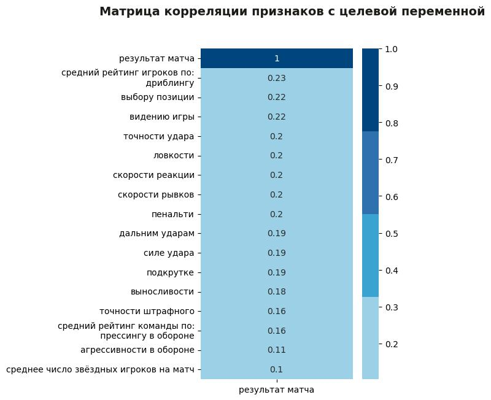

```python
phik_overview = (teams_df
                 .query('season == "2015/2016"')
                 [['number_of_players_with_rating>=85',
                   'defencePressure',
                   'defenceAggression',
                   'avg_reactions',
                   'avg_vision',
                   'avg_finishing',
                   'avg_dribbling',
                   'avg_curve',
                   'avg_free_kick_accuracy',
                   'avg_sprint_speed',
                   'avg_agility',
                   'avg_shot_power',
                   'avg_stamina',
                   'avg_long_shots',
                   'avg_positioning',
                   'avg_penalties',
                   'result']]
                 .phik_matrix()
                )

fig = plt.figure(figsize=(4, 7))
fig.suptitle('Матрица корреляции признаков с целевой переменной',
             fontsize=14,
             fontweight='demi',
             color='#1B1B17')
ax1 = fig.add_subplot(1, 1, 1)
sns.heatmap(phik_overview[['result']].sort_values(ascending=False, by='result'),
            ax=ax1,
            cmap=['#9CD0E6', '#3BA3D0', '#2F70AF', '#00457E'],
            annot=True,
            yticklabels=['результат матча',
                         'средний рейтинг игроков по:\n дриблингу',
                         'выбору позиции',
                         'видению игры',
                         'точности удара',
                         'ловкости',
                         'скорости реакции',
                         'скорости рывков',
                         'пенальти',
                         'дальним ударам',
                         'силе удара',
                         'подкрутке',
                         'выносливости',
                         'точности штрафного',
                         'средний рейтинг команды по:\n прессингу в обороне',
                         'агрессивности в обороне',
                         'среднее число звёздных игроков на матч'],
            xticklabels=['результат матча'])

plt.show()
# построение тепловой карты с использованием библиотеки phik
```

## Модель множественной классификации

```python
teams_df.head()
# вывод первых 5 строк датафрейма
```

|  | id | country_id | country | league_id | league | season | stage | date | year | month_year | match_api_id | team_api_id | team_fifa_api_id | team_long_name | opposing_team_api_id | opposing_team_long_name | goals_scored | missed_goals | place | buildUpPlaySpeed | buildUpPlayDribbling | buildUpPlayPassing | chanceCreationPassing | chanceCreationCrossing | chanceCreationShooting | defencePressure | defenceAggression | defenceTeamWidth | avg_overall_rating | … |
| --- | --- | --- | --- | --- | --- | --- | --- | --- | --- | --- | --- | --- | --- | --- | --- | --- | --- | --- | --- | --- | --- | --- | --- | --- | --- | --- | --- | --- | --- | --- |
| 0 | 307 | 1 | Belgium | 1 | Belgium Jupiler League | 2009/2010 | 1 | 2009-07-31 | 2009 | 2009-07-01 | 665318 | 9985 | 232.0 | Standard de Liège | 9997 | Sint-Truidense VV | 2 | 2 | home | NaN | NaN | NaN | NaN | NaN | NaN | NaN | NaN | NaN | 71.808501 | … |
| 1 | 308 | 1 | Belgium | 1 | Belgium Jupiler League | 2009/2010 | 1 | 2009-08-02 | 2009 | 2009-08-01 | 665320 | 9986 | 670.0 | Sporting Charleroi | 8342 | Club Brugge KV | 1 | 2 | home | NaN | NaN | NaN | NaN | NaN | NaN | NaN | NaN | NaN | NaN | … |
| 2 | 309 | 1 | Belgium | 1 | Belgium Jupiler League | 2009/2010 | 1 | 2009-08-02 | 2009 | 2009-08-01 | 665321 | 9984 | 1750.0 | KSV Cercle Brugge | 9991 | KAA Gent | 1 | 3 | home | NaN | NaN | NaN | NaN | NaN | NaN | NaN | NaN | NaN | 64.778758 | … |
| 3 | 310 | 1 | Belgium | 1 | Belgium Jupiler League | 2009/2010 | 1 | 2009-08-01 | 2009 | 2009-08-01 | 665322 | 9994 | 2007.0 | Sporting Lokeren | 10000 | SV Zulte-Waregem | 1 | 1 | home | NaN | NaN | NaN | NaN | NaN | NaN | NaN | NaN | NaN | 65.599830 | … |
| 4 | 311 | 1 | Belgium | 1 | Belgium Jupiler League | 2009/2010 | 1 | 2009-08-01 | 2009 | 2009-08-01 | 665323 | 8571 | 100081.0 | KV Kortrijk | 8635 | RSC Anderlecht | 0 | 2 | home | NaN | NaN | NaN | NaN | NaN | NaN | NaN | NaN | NaN | 63.521323 | … |

```python
teams_df.columns
# отображение списка столбцов датафрейма
```

```
Index(['id', 'country_id', 'country', 'league_id', 'league', 'season', 'stage',
       'date', 'year', 'month_year', 'match_api_id', 'team_api_id',
       'team_fifa_api_id', 'team_long_name', 'opposing_team_api_id',
       'opposing_team_long_name', 'goals_scored', 'missed_goals', 'place',
       'buildUpPlaySpeed', 'buildUpPlayDribbling', 'buildUpPlayPassing',
       'chanceCreationPassing', 'chanceCreationCrossing',
       'chanceCreationShooting', 'defencePressure', 'defenceAggression',
       'defenceTeamWidth', 'avg_overall_rating', 'avg_potential',
       'avg_finishing', 'avg_heading_accuracy', 'avg_dribbling', 'avg_curve',
       'avg_free_kick_accuracy', 'avg_ball_control', 'avg_acceleration',
       'avg_sprint_speed', 'avg_agility', 'avg_reactions', 'avg_shot_power',
       'avg_jumping', 'avg_stamina', 'avg_strength', 'avg_long_shots',
       'avg_interceptions', 'avg_positioning', 'avg_vision', 'avg_penalties',
       'avg_marking', 'avg_standing_tackle', 'avg_sliding_tackle',
       'avg_gk_diving', 'avg_gk_handling', 'avg_gk_kicking',
       'avg_gk_positioning', 'avg_gk_reflexes',
       'number_of_players_with_rating>=85', 'goals_diff', 'result', 'win_name',
       'avg_coeff'],
      dtype='object')
```

```python
teams_df_model = teams_df[['season', 'stage',
                           'country',
                           'league',
                           'date', 'year', 'month_year', 'match_api_id', 'team_api_id',
                           'team_fifa_api_id', 'team_long_name', 'opposing_team_api_id',
                           'opposing_team_long_name', 'place',
                           'defencePressure',
                           'defenceAggression',
                           'avg_reactions',
                           'avg_vision',
                           'avg_finishing',
                           'avg_dribbling',
                           'avg_curve',
                           'avg_free_kick_accuracy',
                           'avg_sprint_speed',
                           'avg_agility',
                           'avg_shot_power',
                           'avg_stamina',
                           'avg_long_shots',
                           'avg_positioning',
                           'avg_penalties',
                           'number_of_players_with_rating>=85',
                           'goals_diff',
                           'missed_goals',
                           'goals_scored',
                           'win_name',
                           'result']]
# срез данных
```

Проверим наши данные на наличие пропусков.

```python
teams_df_model.isna().sum()
# подсчёт пропусков
```

```
season                                  0
stage                                   0
country                                 0
league                                  0
date                                    0
year                                    0
month_year                              0
match_api_id                            0
team_api_id                             0
team_fifa_api_id                      194
team_long_name                          0
opposing_team_api_id                    0
opposing_team_long_name                 0
place                                   0
defencePressure                      7676
defenceAggression                    7676
avg_reactions                        4047
avg_vision                           5574
avg_finishing                        4047
avg_dribbling                        4047
avg_curve                            5574
avg_free_kick_accuracy               4047
avg_sprint_speed                     4047
avg_agility                          5574
avg_shot_power                       4047
avg_stamina                          4047
avg_long_shots                       4047
avg_positioning                      4047
avg_penalties                        4047
number_of_players_with_rating>=85    4047
goals_diff                              0
missed_goals                            0
goals_scored                            0
win_name                                0
result                                  0
dtype: int64
```

```python
teams_df_model = teams_df_model[~((teams_df_model['defencePressure'].isna()) & (teams_df_model['defenceAggression'].isna()))]
# срез данных
```

```python
teams_df_model = teams_df_model[~((teams_df_model['avg_reactions'].isna())
                & (teams_df_model['avg_finishing'].isna())
                & (teams_df_model['avg_dribbling'].isna())
                & (teams_df_model['avg_free_kick_accuracy'].isna())
                & (teams_df_model['avg_sprint_speed'].isna())
                & (teams_df_model['avg_shot_power'].isna())
                & (teams_df_model['avg_stamina'].isna())
                & (teams_df_model['avg_long_shots'].isna())
                & (teams_df_model['avg_positioning'].isna())
                & (teams_df_model['avg_penalties'].isna()))]
# срез данных
```

```python
teams_df_model = teams_df_model[~((teams_df_model['avg_vision'].isna())
                & (teams_df_model['avg_curve'].isna())
                & (teams_df_model['avg_agility'].isna()))]
# срез данных
```

```python
teams_df_model.isna().sum()
# проверка на наличие пропусков после их удаления
```

```
season                               0
stage                                0
country                              0
league                               0
date                                 0
year                                 0
month_year                           0
match_api_id                         0
team_api_id                          0
team_fifa_api_id                     0
team_long_name                       0
opposing_team_api_id                 0
opposing_team_long_name              0
place                                0
defencePressure                      0
defenceAggression                    0
avg_reactions                        0
avg_vision                           0
avg_finishing                        0
avg_dribbling                        0
avg_curve                            0
avg_free_kick_accuracy               0
avg_sprint_speed                     0
avg_agility                          0
avg_shot_power                       0
avg_stamina                          0
avg_long_shots                       0
avg_positioning                      0
avg_penalties                        0
number_of_players_with_rating>=85    0
goals_diff                           0
missed_goals                         0
goals_scored                         0
win_name                             0
result                               0
dtype: int64
```

```python
len(teams_df_model['team_api_id'].unique())
# подсчёт количества уникальных id команд
```

```
270
```

Для обучения модели выберем сезон 2015/2016 как самый релевантный.

```python
len(set(list(teams_df_model.query('season == "2015/2016"')['team_api_id'].unique())))
# подсчёт количества уникальных id команд в сезоне 2015/2016
```

```
176
```

```python
teams_df_model_2016 = teams_df_model.query('season == "2015/2016"').reset_index(drop=True)
# срез данных по сезону 2015/2016
```

```python
teams_list = list(teams_df_model_2016['team_api_id'].unique())
# сохранение списка с командами сезона 2015/2016
```

Создадим функции для подсчёта результативности игр и средних значений игровых атрибутов для каждой команды в сезоне с целью использования их в формировании тренировочной выборки.

```python
def calculate_team_stat(data, team):
    goals_scored_agg = 0
    goals_missed_agg = 0

    match_win = 0
    match_draw = 0
    match_lost = 0

    total_score = 0

    match_count = 0

    defencePressure_agg = 0
    defenceAggression_agg = 0
    reactions_agg = 0
    vision_agg = 0
    finishing_agg = 0
    dribbling_agg = 0
    curve_agg = 0
    free_kick_accuracy_agg = 0
    sprint_speed_agg = 0
    agility_agg = 0
    shot_power_agg = 0
    stamina_agg = 0
    long_shots_agg = 0
    positioning_agg = 0
    penalties_agg = 0
    top_players_agg = 0
    win_home_games = 0
    win_away_games = 0

    for i in range(len(data)):

        if (data['team_api_id'][i] == team):
            match_count += 1

            goals_scored_agg += data['goals_scored'][i]
            goals_missed_agg += data['missed_goals'][i]

            if (data['goals_scored'][i] > data['missed_goals'][i]):
                total_score += 3
                match_win += 1
            elif (data['goals_scored'][i] < data['missed_goals'][i]):
                match_lost += 1
            else:
                total_score += 1
                match_draw += 1

            if (data['place'][i] == "home" and (data['result'][i] == "win" or data['result'][i] == "draw")):
                win_home_games += 1
            elif (data['place'][i] == "away" and (data['result'][i] == "win" or data['result'][i] == "draw")):
                win_away_games += 1
            else:
                win_home_games += 0
                win_away_games += 0

            defencePressure_agg += data['defencePressure'][i]
            defenceAggression_agg += data['defenceAggression'][i]
            reactions_agg += data['avg_reactions'][i]
            vision_agg += data['avg_vision'][i]
            finishing_agg += data['avg_finishing'][i]
            dribbling_agg += data['avg_dribbling'][i]
            curve_agg += data['avg_curve'][i]
            free_kick_accuracy_agg += data['avg_free_kick_accuracy'][i]
            sprint_speed_agg += data['avg_sprint_speed'][i]
            agility_agg += data['avg_agility'][i]
            shot_power_agg += data['avg_shot_power'][i]
            stamina_agg += data['avg_stamina'][i]
            long_shots_agg += data['avg_long_shots'][i]
            positioning_agg += data['avg_positioning'][i]
            penalties_agg += data['avg_penalties'][i]
            top_players_agg += data['number_of_players_with_rating>=85'][i]

    avg_defencePressure_agg = round(defencePressure_agg / match_count, 2)
    avg_defenceAggression_agg = round(defenceAggression_agg / match_count, 2)
    avg_reactions_agg = round(reactions_agg / match_count, 2)
    avg_vision_agg = round(vision_agg / match_count, 2)
    avg_finishing_agg = round(finishing_agg / match_count, 2)
    avg_dribbling_agg = round(dribbling_agg / match_count, 2)
    avg_curve_agg = round(curve_agg / match_count, 2)
    avg_free_kick_accuracy_agg = round(free_kick_accuracy_agg / match_count, 2)
    avg_sprint_speed_agg = round(sprint_speed_agg / match_count, 2)
    avg_agility_agg = round(agility_agg / match_count, 2)
    avg_shot_power_agg = round(shot_power_agg / match_count, 2)
    avg_stamina_agg = round(stamina_agg / match_count, 2)
    avg_long_shots_agg = round(long_shots_agg / match_count, 2)
    avg_positioning_agg = round(positioning_agg / match_count, 2)
    avg_penalties_agg = round(penalties_agg / match_count, 2)
    avg_top_players_agg = round(top_players_agg / match_count, 2)

    return [match_win,
            match_draw,
            match_lost,
            goals_scored_agg,
            goals_missed_agg,
            total_score,
            avg_defencePressure_agg,
            avg_defenceAggression_agg,
            avg_reactions_agg,
            avg_vision_agg,
            avg_finishing_agg,
            avg_dribbling_agg,
            avg_curve_agg,
            avg_free_kick_accuracy_agg,
            avg_sprint_speed_agg,
            avg_agility_agg,
            avg_shot_power_agg,
            avg_stamina_agg,
            avg_long_shots_agg,
            avg_positioning_agg,
            avg_penalties_agg,
            avg_top_players_agg,
            win_home_games,
            win_away_games]

# создание функции для подсчёта статистики для каждой команды
```

```python
calculate_team_stat(teams_df_model_2016, 8571)
# проверка работы функции calculate_team_stat
```

```
[6,
 7,
 8,
 21,
 27,
 25,
 46.0,
 45.0,
 63.24,
 52.52,
 43.12,
 49.55,
 44.98,
 46.14,
 63.17,
 56.92,
 57.42,
 64.73,
 48.55,
 48.35,
 49.47,
 0.0,
 9,
 4]
```

```python
def calculate_all_team_stat(data):
    place_cat = collections.defaultdict(list)
    for team in teams_list:
        team_vector = calculate_team_stat(data, team)
        place_cat[team] = team_vector
    return place_cat

# создание функции для подсчёта статистики всех команд за сезон
```

```python
calculate_all_team_stat(teams_df_model_2016)
# проверка работы функции calculate_all_team_stat
```

```
defaultdict(list,
            {8571: [6,
              7,
              8,
              21,
              27,
              25,
              46.0,
              45.0,
              63.24,
              52.52,
              43.12,
              49.55,
              44.98,
              46.14,
              63.17,
              56.92,
              57.42,
              64.73,
              48.55,
              48.35,
              49.47,
              0.0,
              9,
              4],
             9987: [8,
              4,
              9,
              23,
              22,
              28,
              36.0,
              57.0,
              66.24,
              54.35,
              46.28,
              56.46,
              47.64,
              46.36,
              71.36,
```

[output cut: 4170 more lines]

```
              57.7,
              47.51,
              57.74,
              50.01,
              49.05,
              69.48,
              65.18,
              62.82,
              67.26,
              52.84,
              55.44,
              55.43,
              0.0,
              5,
              4]})
```

```python
def get_train_data(data):
    total_matches = 0

    place_cat = data
    total_matches += len(place_cat.index)
    num_features = 24
    #размерность
    x_train = np.zeros((total_matches, num_features))
    y_train = np.zeros((total_matches))
    index_count = 0

    team_vectors = calculate_all_team_stat(data)
    place_cat = data
    total_matches_cat = len(place_cat.index)
    x_train_cat = np.zeros((total_matches_cat, num_features))
    y_train_cat = np.zeros((total_matches_cat))
    count = 0

    for index, row in place_cat.iterrows():
        team = row['team_api_id']
        team_vector = team_vectors[team]
        rival = row['opposing_team_api_id']
        rival_vector = team_vectors[rival]

        difference = [a - b for a, b in zip(team_vector, rival_vector)]

        if len(difference) != 0:
            x_train_cat[count] = difference
        if team == row['win_name']:
            y_train_cat[count] = 2
        elif rival == row['win_name']:
            y_train_cat[count] = 0
        else:
            y_train_cat[count] = 1
        count += 1
    x_train[index_count:total_matches_cat+index_count] = x_train_cat
    y_train[index_count:total_matches_cat+index_count] = y_train_cat
    index_count += total_matches_cat
    return x_train, y_train

# создание функции для формирования тренировочной выборки
```

3 исхода:

- 2 - win
- 0 - lose
- 1 - draw

```python
x_train, y_train = get_train_data(teams_df_model_2016)
# получение тренировочной выборки с помощью функции get_train_data
```

```python
x_train, y_train
# тренировочная выборка
```

```
(array([[-2.,  3., -1., ...,  0.,  1.,  0.],
        [ 0.,  0.,  0., ...,  0.,  0.,  0.],
        [ 4.,  1., -5., ...,  0.,  0.,  5.],
        ...,
        [-4.,  0.,  2., ...,  0., -2., -2.],
        [ 0.,  0.,  0., ...,  0.,  0.,  0.],
        [ 7., -6., -1., ...,  0.,  0.,  1.]]),
 array([2., 2., 2., ..., 0., 1., 0.]))
```

```python
scaler = StandardScaler()
# создаём объект для стандартизирования
x_train_scaled = scaler.fit_transform(x_train)
# приводим значения всех признаков к единой шкале
clf = LogisticRegression()
# создаём объект для работы с моделью
clf = clf.fit(x_train_scaled, y_train)
# настраиваем модель на данные
```

```python
def create_prediction(team_1_vector, team_2_vector):
    difference = [[a - b for a, b in zip(team_1_vector, team_2_vector)]]
    difference_scaled = scaler.transform(difference)
    predictions = clf.predict(difference_scaled)
    y_proba = clf.predict_proba(difference_scaled)
    return predictions, y_proba

# создание функции для предсказания исходов матчей между двумя командами
```

```python
teams_df_model_2014 = teams_df_model.query('season == "2013/2014"').reset_index(drop=True)
# срез данных по сезону 2013/2014
```

```python
team_1_id = 9991
team_2_id = 8475

create_prediction(calculate_team_stat(teams_df_model_2014, team_1_id), calculate_team_stat(teams_df_model_2014, team_2_id))
# проверка работы функции create_prediction
```

```
(array([2.]), array([[0.23108896, 0.29053445, 0.47837659]]))
```

```python
team_1_id = 8475
team_2_id = 9991

create_prediction(calculate_team_stat(teams_df_model_2014, team_1_id), calculate_team_stat(teams_df_model_2014, team_2_id))
# проверка работы функции create_prediction
```

```
(array([0.]), array([[0.45444614, 0.28695966, 0.2585942 ]]))
```

```python
team_1_id = 8573
team_2_id = 9991

create_prediction(calculate_team_stat(teams_df_model_2014, team_1_id), calculate_team_stat(teams_df_model_2014, team_2_id))
# проверка работы функции create_prediction
```

```
(array([2.]), array([[0.26402877, 0.29103733, 0.4449339 ]]))
```

## Проверка модели на точность

Протестируем нашу модель на данных сезона 2013/2014.

```python
prediction = []
for i in range(len(teams_df_model_2014)):
    try:
        pred, y_prob = create_prediction(calculate_team_stat(teams_df_model_2014, teams_df_model_2014['team_api_id'][i]), calculate_team_stat(teams_df_model_2014, teams_df_model_2014['opposing_team_api_id'][i]))
        prediction.append(pred[0])
    except:
        prediction.append(np.nan)
teams_df_model_2014['prediction'] = prediction
```

```python
win_probability = []
for i in range(len(teams_df_model_2014)):
    try:
        pred, y_prob = create_prediction(calculate_team_stat(teams_df_model_2014, teams_df_model_2014['team_api_id'][i]), calculate_team_stat(teams_df_model_2014, teams_df_model_2014['opposing_team_api_id'][i]))
        win_probability.append(y_prob[:, 2][0])
    except:
        win_probability.append(np.nan)
teams_df_model_2014['win_probability'] = win_probability
```

```python
lose_probability = []
for i in range(len(teams_df_model_2014)):
    try:
        pred, y_prob = create_prediction(calculate_team_stat(teams_df_model_2014, teams_df_model_2014['team_api_id'][i]), calculate_team_stat(teams_df_model_2014, teams_df_model_2014['opposing_team_api_id'][i]))
        lose_probability.append(y_prob[:, 0][0])
    except:
        lose_probability.append(np.nan)
teams_df_model_2014['lose_probability'] = lose_probability
```

```python
draw_probability = []
for i in range(len(teams_df_model_2014)):
    try:
        pred, y_prob = create_prediction(calculate_team_stat(teams_df_model_2014, teams_df_model_2014['team_api_id'][i]), calculate_team_stat(teams_df_model_2014, teams_df_model_2014['opposing_team_api_id'][i]))
        draw_probability.append(y_prob[:, 1][0])
    except:
        draw_probability.append(np.nan)
teams_df_model_2014['draw_probability'] = draw_probability
```

```python
teams_df_model_2014['prediction_name'] = teams_df_model_2014['prediction'].apply(lambda x: 'win' if x == 2 else ('lose' if x == 0 else 'draw'))
```

```python
def check_prediction(df):
    if df['result'] == df['prediction_name']:
        return 1
    else:
        return 0
```

```python
teams_df_model_2014['check_prediction'] = teams_df_model_2014.apply(check_prediction, axis=1)
```

```python
accuracy = teams_df_model_2014['check_prediction'].sum() / teams_df_model_2014['check_prediction'].count()
print(f'Точность модели составляет {round(accuracy * 100, 2)}%')
```

```
Точность модели составляет 54.49%
```

```python
teams_df_model_2014.head()
# вывод первых 5 строк датафрейма
```

|  | season | stage | country | league | date | year | month_year | match_api_id | team_api_id | team_fifa_api_id | team_long_name | opposing_team_api_id | opposing_team_long_name | place | defencePressure | defenceAggression | avg_reactions | avg_vision | avg_finishing | avg_dribbling | avg_curve | avg_free_kick_accuracy | avg_sprint_speed | avg_agility | avg_shot_power | avg_stamina | avg_long_shots | avg_positioning | avg_penalties | … |
| --- | --- | --- | --- | --- | --- | --- | --- | --- | --- | --- | --- | --- | --- | --- | --- | --- | --- | --- | --- | --- | --- | --- | --- | --- | --- | --- | --- | --- | --- | --- |
| 0 | 2013/2014 | 1 | Belgium | Belgium Jupiler League | 2014-03-29 | 2014 | 2014-03-01 | 1677179 | 8475 | 110913.0 | Waasland-Beveren | 9989 | Lierse SK | home | 25.0 | 37.0 | 64.279253 | 53.534524 | 46.572247 | 52.030015 | 45.845931 | 48.838135 | 63.802971 | 61.671243 | 62.506969 | 65.160475 | 49.004515 | 46.884033 | 52.807929 | … |
| 1 | 2013/2014 | 1 | Belgium | Belgium Jupiler League | 2014-03-29 | 2014 | 2014-03-01 | 1677180 | 9991 | 674.0 | KAA Gent | 8573 | KV Oostende | home | 55.0 | 59.0 | 65.339235 | 55.397775 | 46.354064 | 56.344551 | 48.332327 | 48.875162 | 66.663917 | 64.972907 | 58.450497 | 69.265241 | 52.523987 | 53.050341 | 51.412803 | … |
| 2 | 2013/2014 | 2 | Belgium | Belgium Jupiler League | 2014-04-05 | 2014 | 2014-04-01 | 1677181 | 9989 | 239.0 | Lierse SK | 9991 | KAA Gent | home | 38.0 | 49.0 | 58.809181 | 53.866139 | 39.354726 | 57.860367 | 45.542216 | 44.077475 | 62.005479 | 65.537811 | 45.495591 | 57.854466 | 44.891434 | 49.085470 | 47.493803 | … |
| 3 | 2013/2014 | 2 | Belgium | Belgium Jupiler League | 2014-04-05 | 2014 | 2014-04-01 | 1677182 | 8573 | 682.0 | KV Oostende | 8475 | Waasland-Beveren | home | 42.0 | 47.0 | 62.340751 | 55.654814 | 46.783264 | 56.110913 | 49.707601 | 50.655574 | 64.657375 | 64.573781 | 59.103688 | 65.556163 | 51.110653 | 51.806519 | 55.437054 | … |
| 4 | 2013/2014 | 3 | Belgium | Belgium Jupiler League | 2014-04-12 | 2014 | 2014-04-01 | 1677183 | 9991 | 674.0 | KAA Gent | 8475 | Waasland-Beveren | home | 55.0 | 59.0 | 65.638598 | 57.128201 | 48.478734 | 59.331399 | 53.639477 | 50.579524 | 68.397839 | 67.440426 | 62.283966 | 66.757644 | 54.435490 | 54.403196 | 51.202756 | … |

```python
clf.coef_[0]
# получение коэффициентов модели
```

```
array([-0.12246647,  0.07654187,  0.27397955, -0.04485779,  0.04636328,
       -0.11449922, -0.01692882, -0.00112256, -0.03501324, -0.0131047 ,
       -0.04055533,  0.0839891 , -0.01374585,  0.0167307 ,  0.02686785,
       -0.03779339, -0.04146473, -0.01624858,  0.05635608, -0.03802815,
       -0.00596657, -0.00906486, -0.06072361, -0.07567901])
```

```python
features_list = ['match_win',
                 'match_draw',
                 'match_lost',
                 'goals_scored_agg',
                 'goals_missed_agg',
                 'total_score',
                 'avg_defencePressure_agg',
                 'avg_defenceAggression_agg',
                 'avg_reactions_agg',
                 'avg_vision_agg',
                 'avg_finishing_agg',
                 'avg_dribbling_agg',
                 'avg_curve_agg',
                 'avg_free_kick_accuracy_agg',
                 'avg_sprint_speed_agg',
                 'avg_agility_agg',
                 'avg_shot_power_agg',
                 'avg_stamina_agg',
                 'avg_long_shots_agg',
                 'avg_positioning_agg',
                 'avg_penalties_agg',
                 'avg_top_players_agg',
                 'win_home_games',
                 'win_away_games']
# создание списка признаков
```

```python
for feature_number, feature_name in enumerate(features_list):
    exp_weight = math.exp(clf.coef_[0, feature_number])
    print(f"{feature_name:<40}: {exp_weight:+.6f}")
# вывод коэффициентов признаков в модели
```

```
match_win                               : +0.884736
match_draw                              : +1.079547
match_lost                              : +1.315188
goals_scored_agg                        : +0.956133
goals_missed_agg                        : +1.047455
total_score                             : +0.891813
avg_defencePressure_agg                 : +0.983214
avg_defenceAggression_agg               : +0.998878
avg_reactions_agg                       : +0.965593
avg_vision_agg                          : +0.986981
avg_finishing_agg                       : +0.960256
avg_dribbling_agg                       : +1.087617
avg_curve_agg                           : +0.986348
avg_free_kick_accuracy_agg              : +1.016871
avg_sprint_speed_agg                    : +1.027232
avg_agility_agg                         : +0.962912
avg_shot_power_agg                      : +0.959383
avg_stamina_agg                         : +0.983883
avg_long_shots_agg                      : +1.057974
avg_positioning_agg                     : +0.962686
avg_penalties_agg                       : +0.994051
avg_top_players_agg                     : +0.990976
win_home_games                          : +0.941083
win_away_games                          : +0.927114
```